# GARCH Markdown

Steve and Sara

October 27, 2016

In this script we try and figure out how to use SARIMA and a GARCH model to fit the flu data. To read more about the data, see: https://predict.phiresearchlab.org/legacy/flu/targets.html and https://github.com/cdcepi/flu-tools-2015-16

To get the data see the `data-pulling.R` script in the `code` folder.

GARCH is often used on the difference of the log values (roughly the percent change). GARCH can be viewed sort of like an ARMA that accounts for non-constant variance. Thus, we will first try to fit an ARMA model for the difference of the logs, which is what GARCH is usually performed on.

```
## [1] 1 0 1
```

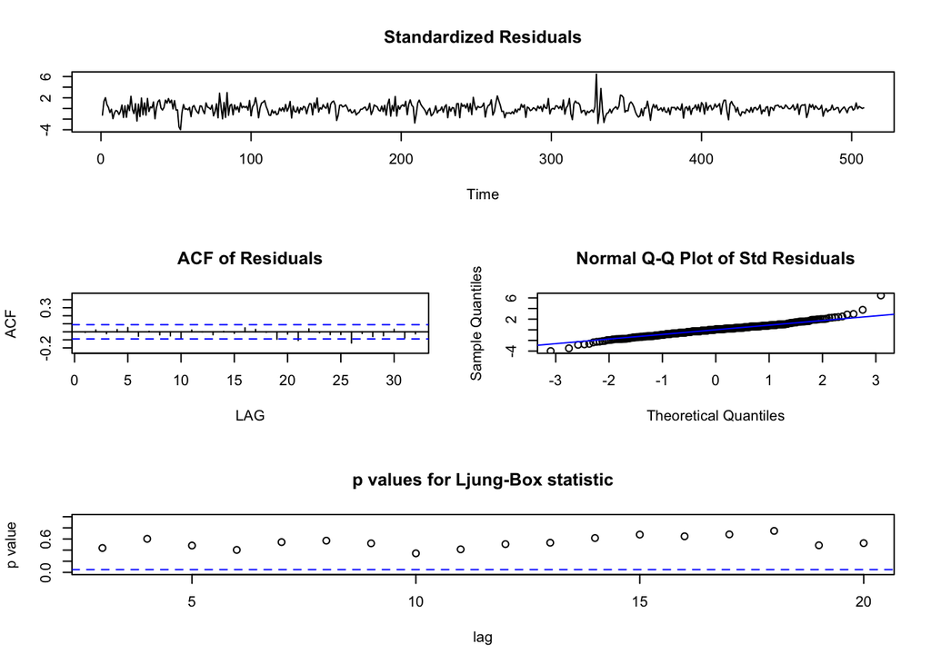

What happens if we make the period 52 weeks:

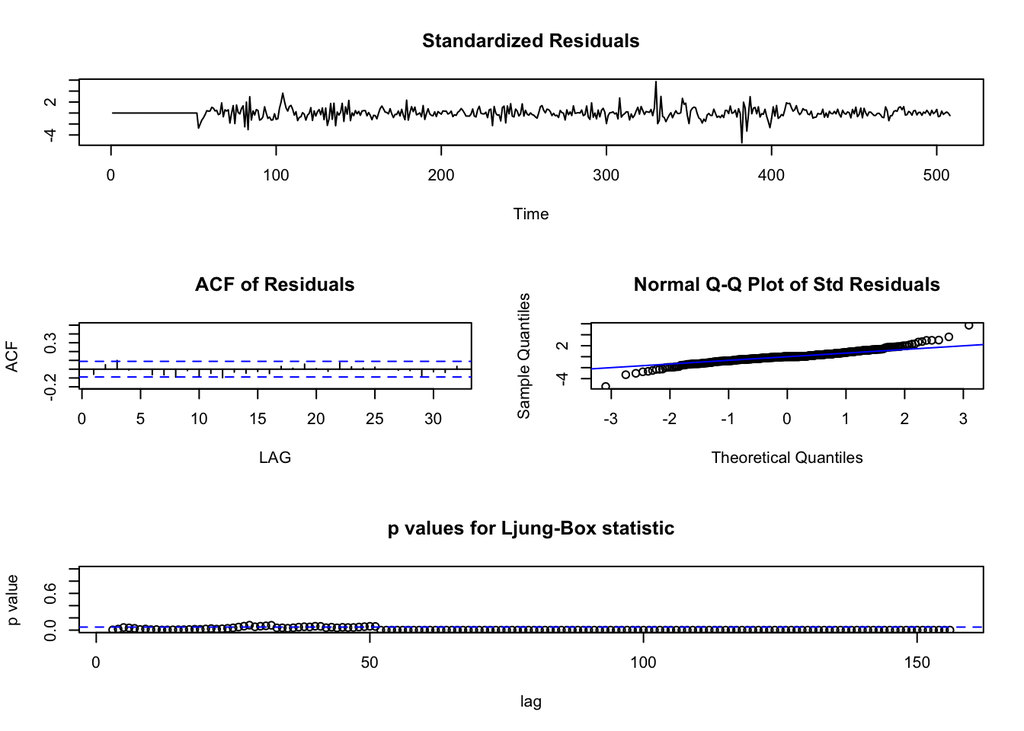

We’ll use that first SARIMA to predict the test set (since we can’t use the periodic component for GARCH anyways)

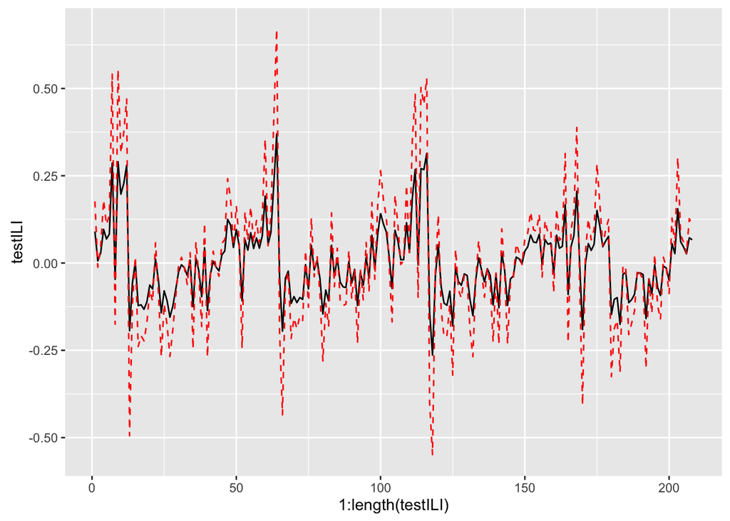

And we can calculate the mean absolute error of our predictions:

```r
mean(abs(ILI_preds$residuals))
```

```
## [1] 0.06770364
```

Next we try to build a GARCH model using an ARMA(1,1) (similar to the one we got with `auto.arima()`). But we need to try a few GARCH(m,r) models

```r
ILI_garch10 <- garchFit(~arma(1,1)+garch(1,0), dILI, trace=FALSE)
summary(ILI_garch10)
```

```
##
## Title:
##  GARCH Modelling
##
## Call:
##  garchFit(formula = ~arma(1, 1) + garch(1, 0), data = dILI, trace = FALSE)
##
## Mean and Variance Equation:
##  data ~ arma(1, 1) + garch(1, 0)
## <environment: 0x7f8bf8007550>
##  [data = dILI]
##
## Conditional Distribution:
##  norm
##
## Coefficient(s):
##          mu          ar1          ma1        omega       alpha1
## -0.00051063   0.70628062  -0.45290031   0.01587145   0.14851540
##
## Std. Errors:
##  based on Hessian
##
## Error Analysis:
##          Estimate  Std. Error  t value Pr(>|t|)
## mu     -0.0005106   0.0032343   -0.158    0.875
## ar1     0.7062806   0.0895009    7.891 2.89e-15 ***
## ma1    -0.4529003   0.1138892   -3.977 6.99e-05 ***
## omega   0.0158714   0.0012764   12.435  < 2e-16 ***
## alpha1  0.1485154   0.0616284    2.410    0.016 *
## ---
## Signif. codes:  0 '***' 0.001 '**' 0.01 '*' 0.05 '.' 0.1 ' ' 1
##
## Log Likelihood:
##  297.8196    normalized:  0.586259
##
## Description:
##  Thu Oct 27 15:46:39 2016 by user:
##
##
## Standardised Residuals Tests:
##                                 Statistic p-Value
##  Jarque-Bera Test   R    Chi^2  527.8409  0
##  Shapiro-Wilk Test  R    W      0.9613053 2.689856e-10
##  Ljung-Box Test     R    Q(10)  7.499829  0.6775642
##  Ljung-Box Test     R    Q(15)  8.58096   0.8983895
##  Ljung-Box Test     R    Q(20)  14.84772  0.785054
##  Ljung-Box Test     R^2  Q(10)  29.5729   0.001005793
##  Ljung-Box Test     R^2  Q(15)  30.47922  0.0103061
##  Ljung-Box Test     R^2  Q(20)  44.97214  0.001113106
##  LM Arch Test       R    TR^2   32.13994  0.001316609
##
## Information Criterion Statistics:
##       AIC       BIC       SIC      HQIC
## -1.152833 -1.111194 -1.153024 -1.136505
```

```r
ILI_garch20 <- garchFit(~arma(1,1)+garch(2,0), dILI, trace=FALSE)
summary(ILI_garch20)
```

```
##
## Title:
##  GARCH Modelling
##
## Call:
##  garchFit(formula = ~arma(1, 1) + garch(2, 0), data = dILI, trace = FALSE)
##
## Mean and Variance Equation:
##  data ~ arma(1, 1) + garch(2, 0)
## <environment: 0x7f8bf88be040>
##  [data = dILI]
##
## Conditional Distribution:
##  norm
##
## Coefficient(s):
##         mu         ar1         ma1       omega      alpha1      alpha2
## -0.0014588   0.6691382  -0.3707527   0.0132957   0.1652838   0.1319534
##
## Std. Errors:
##  based on Hessian
##
## Error Analysis:
##         Estimate  Std. Error  t value Pr(>|t|)
## mu     -0.001459    0.003723   -0.392  0.69520
## ar1     0.669138    0.095144    7.033 2.02e-12 ***
## ma1    -0.370753    0.118449   -3.130  0.00175 **
## omega   0.013296    0.001325   10.034  < 2e-16 ***
## alpha1  0.165284    0.063559    2.600  0.00931 **
## alpha2  0.131953    0.057020    2.314  0.02066 *
## ---
## Signif. codes:  0 '***' 0.001 '**' 0.01 '*' 0.05 '.' 0.1 ' ' 1
##
## Log Likelihood:
##  303.9105    normalized:  0.598249
##
## Description:
##  Thu Oct 27 15:46:39 2016 by user:
##
##
## Standardised Residuals Tests:
##                                 Statistic p-Value
##  Jarque-Bera Test   R    Chi^2  643.6871  0
##  Shapiro-Wilk Test  R    W      0.9593158 1.240062e-10
##  Ljung-Box Test     R    Q(10)  10.75235  0.3771351
##  Ljung-Box Test     R    Q(15)  12.48991  0.6416319
##  Ljung-Box Test     R    Q(20)  18.29773  0.5678023
##  Ljung-Box Test     R^2  Q(10)  5.017305  0.890019
##  Ljung-Box Test     R^2  Q(15)  5.680237  0.984633
##  Ljung-Box Test     R^2  Q(20)  20.92927  0.4013065
##  LM Arch Test       R    TR^2   5.946807  0.9187397
##
## Information Criterion Statistics:
##       AIC       BIC       SIC      HQIC
## -1.172876 -1.122910 -1.173151 -1.153283
```

```r
ILI_garch11 <- garchFit(~arma(1,1)+garch(1,1), dILI, trace=FALSE)
summary(ILI_garch11)
```

```
##
## Title:
##  GARCH Modelling
##
## Call:
##  garchFit(formula = ~arma(1, 1) + garch(1, 1), data = dILI, trace = FALSE)
##
## Mean and Variance Equation:
##  data ~ arma(1, 1) + garch(1, 1)
## <environment: 0x7f8bf53e5d18>
##  [data = dILI]
##
## Conditional Distribution:
##  norm
##
## Coefficient(s):
##          mu          ar1          ma1        omega       alpha1
## -0.00041124   0.64560376  -0.41333437   0.00062992   0.07217055
##       beta1
##  0.89535307
##
## Std. Errors:
##  based on Hessian
##
## Error Analysis:
##          Estimate  Std. Error  t value Pr(>|t|)
## mu     -0.0004112   0.0032478   -0.127  0.89924
## ar1     0.6456038   0.1122164    5.753 8.76e-09 ***
## ma1    -0.4133344   0.1352681   -3.056  0.00225 **
## omega   0.0006299   0.0004227    1.490  0.13615
## alpha1  0.0721705   0.0233595    3.090  0.00200 **
## beta1   0.8953531   0.0344965   25.955  < 2e-16 ***
## ---
## Signif. codes:  0 '***' 0.001 '**' 0.01 '*' 0.05 '.' 0.1 ' ' 1
##
## Log Likelihood:
##  306.8869    normalized:  0.6041081
##
## Description:
##  Thu Oct 27 15:46:39 2016 by user:
##
##
## Standardised Residuals Tests:
##                                 Statistic p-Value
##  Jarque-Bera Test   R    Chi^2  622.9638  0
##  Shapiro-Wilk Test  R    W      0.9621317 3.737849e-10
##  Ljung-Box Test     R    Q(10)  10.73493  0.3785391
##  Ljung-Box Test     R    Q(15)  13.50234  0.5635572
##  Ljung-Box Test     R    Q(20)  17.21619  0.6388943
##  Ljung-Box Test     R^2  Q(10)  3.203562  0.9762194
##  Ljung-Box Test     R^2  Q(15)  4.354435  0.9963246
##  Ljung-Box Test     R^2  Q(20)  14.17617  0.8214523
##  LM Arch Test       R    TR^2   3.924915  0.9847534
##
## Information Criterion Statistics:
##       AIC       BIC       SIC      HQIC
## -1.184594 -1.134628 -1.184869 -1.165001
```

```r
ILI_garch21 <- garchFit(~arma(1,1)+garch(2,1), dILI, trace=FALSE)
summary(ILI_garch21)
```

```
##
## Title:
##  GARCH Modelling
##
## Call:
##  garchFit(formula = ~arma(1, 1) + garch(2, 1), data = dILI, trace = FALSE)
##
## Mean and Variance Equation:
##  data ~ arma(1, 1) + garch(2, 1)
## <environment: 0x7f8bf8e8c040>
##  [data = dILI]
##
## Conditional Distribution:
##  norm
##
## Coefficient(s):
##          mu          ar1          ma1        omega       alpha1
## -0.00040453   0.64902151  -0.41791435   0.00063131   0.07271866
##      alpha2        beta1
##  0.00000001   0.89467898
##
## Std. Errors:
##  based on Hessian
##
## Error Analysis:
##          Estimate  Std. Error  t value Pr(>|t|)
## mu     -4.045e-04   3.223e-03   -0.126  0.90012
## ar1     6.490e-01   1.135e-01    5.719 1.07e-08 ***
## ma1    -4.179e-01   1.355e-01   -3.083  0.00205 **
## omega   6.313e-04   4.279e-04    1.475  0.14008
## alpha1  7.272e-02   3.907e-02    1.861  0.06271 .
## alpha2  1.000e-08   4.558e-02    0.000  1.00000
## beta1   8.947e-01   3.798e-02   23.556  < 2e-16 ***
## ---
## Signif. codes:  0 '***' 0.001 '**' 0.01 '*' 0.05 '.' 0.1 ' ' 1
##
## Log Likelihood:
##  307.0597    normalized:  0.6044482
##
## Description:
##  Thu Oct 27 15:46:40 2016 by user:
##
##
## Standardised Residuals Tests:
##                                 Statistic p-Value
##  Jarque-Bera Test   R    Chi^2  630.5615  0
##  Shapiro-Wilk Test  R    W      0.9620073 3.556224e-10
##  Ljung-Box Test     R    Q(10)  10.68587  0.3825092
##  Ljung-Box Test     R    Q(15)  13.44066  0.5683017
##  Ljung-Box Test     R    Q(20)  17.14843  0.6433154
##  Ljung-Box Test     R^2  Q(10)  3.162441  0.9773385
##  Ljung-Box Test     R^2  Q(15)  4.326034  0.9964579
##  Ljung-Box Test     R^2  Q(20)  14.14356  0.8231433
##  LM Arch Test       R    TR^2   3.889643  0.9853464
##
## Information Criterion Statistics:
##       AIC       BIC       SIC      HQIC
## -1.181337 -1.123043 -1.181710 -1.158478
```

```r
ILI_garch10@fit$ics
```

```
##       AIC       BIC       SIC      HQIC
## -1.152833 -1.111194 -1.153024 -1.136505
```

```r
ILI_garch20@fit$ics
```

```
##       AIC       BIC       SIC      HQIC
## -1.172876 -1.122910 -1.173151 -1.153283
```

```r
ILI_garch11@fit$ics
```

```
##       AIC       BIC       SIC      HQIC
## -1.184594 -1.134628 -1.184869 -1.165001
```

```r
ILI_garch21@fit$ics
```

```
##       AIC       BIC       SIC      HQIC
## -1.181337 -1.123043 -1.181710 -1.158478
```

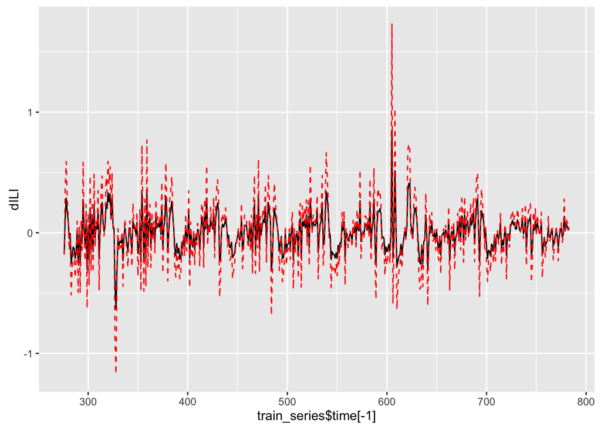

The GARCH package in R doesn’t seem to allow you to make predictions with the same model for a new set of data. Instead, you need to re-fit the model after each step and predict the next one. This means that it has more information than the SARIMA one does for making predictions at each step, as the SARIMA is only fit to the training data.

```r
whole_series <- bind_rows(train_series, test_series)
garch_preds <- c()
for(i in 0:(nrow(test_series)-2)){
    new_train <- whole_series[1:(nrow(train_series)+i),]
    new_dILI <- as.ts(diff(log(new_train$ILI)))
    new_fit <- garchFit(~arma(1,1)+garch(1,1), new_dILI, trace=F)
    garch_preds[i+1] <- predict(new_fit, n.ahead=1)$meanForecast
}
```

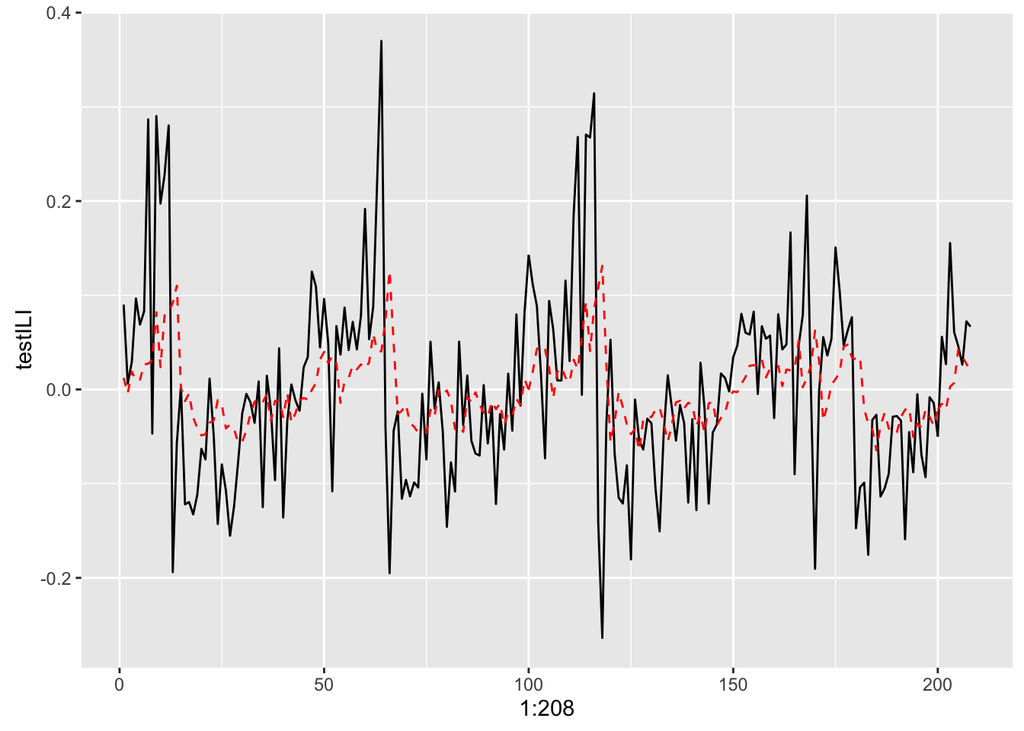

Unlike SARIMA, the GARCH model does not miss over the top, but rather by not going far enough in its predictions. The MAE is similar to that of the SARIMA model (but worse, despite having a data advantage):

```r
mean(abs(testILI-garch_preds))
```

```
## [1] 0.07066403
```

Lastly, lets see what happens if we convert these values back to their original form and take the MAEs:

```r
ILI_SARIMA <- exp(cumsum(c(log(train_series$ILI[nrow(train_series)]),ILI_preds$residuals))[-1])
mean(abs(ILI_SARIMA-test_series$ILI[-nrow(test_series)]))
```

```
## [1] 0.4116419
```

```r
ILI_GARCH <- exp(cumsum(c(log(train_series$ILI[nrow(train_series)]),garch_preds))[-1])
mean(abs(ILI_GARCH-test_series$ILI[-nrow(test_series)]))
```

```
## [1] 0.5490981
```

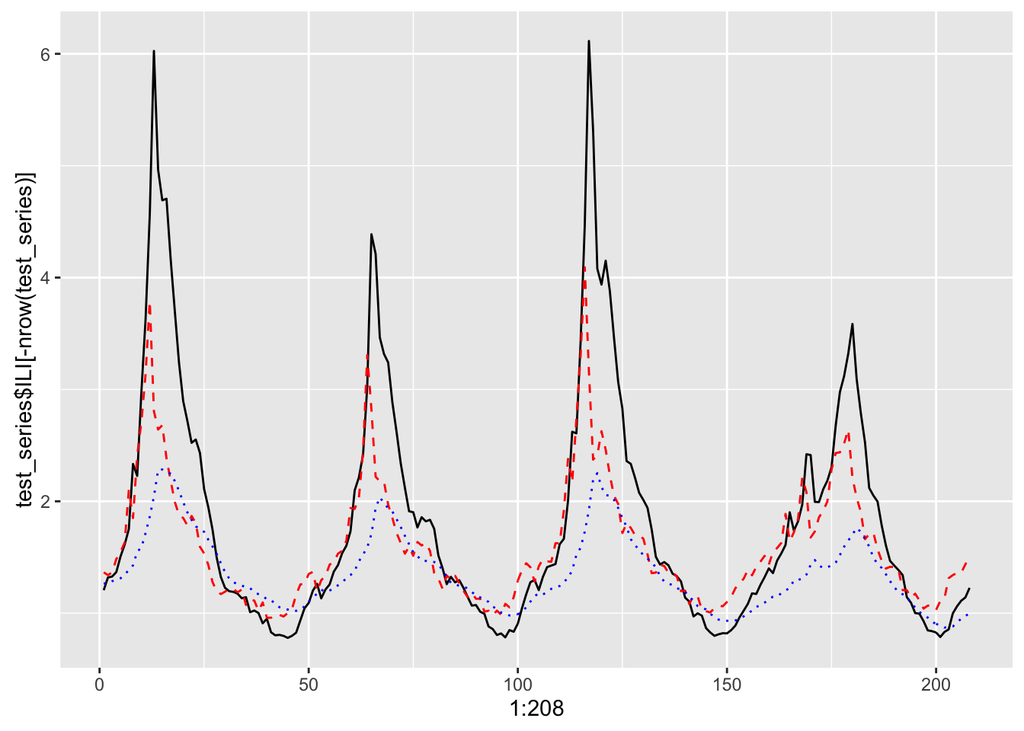

```r
ggplot() +
    geom_line(aes(x=1:208, y=test_series$ILI[-nrow(test_series)])) +
    geom_line(aes(x=1:208, y=ILI_SARIMA), color="red", linetype="dashed") +
    geom_line(aes(x=1:208, y=ILI_GARCH), color="blue", linetype="dotted")
```

After transformation, you can see that the GARCH method is really looking for reversion to the mean and not doing a good job at all of capturing the peaks or nadirs. Seems like the SARIMA model is better for use with this dataset.